Harpur College · Dean’s Office

# Curricular Planning Form — Info & FAQ

## Accessing and using the form

**How do I access the Harpur Curricular Planning form?**

Log in to my.Binghamton — under the “Other” menu at the bottom you’ll see “Harpur Curricular Planning” — click that.

[figure not shown]

You’ll now see this page:

[figure not shown]

Choose the semester you want to enter, and select your own department or program.

At the top of the next page, you’ll see 2 required, one-time questions:

[figure not shown]

Once you answer these, they’ll no longer appear on the form, though you can edit them later (see below).

In the “Course Entry” section beneath, please enter information for a course.

[figure not shown]

Notice the first option in each of the drop-down menus allows you to add an instructor or a course not found in the pre-populated list, for example:

[figure not shown]

This will allow you to choose an instructor from another department (relatively rare case), enter an instructor new to Binghamton (e.g. a new adjunct, a fairly common case), or enter a TBA instructor if your department is searching (a common case).

[figure not shown]

If the instructor is *not* external to BU, begin typing their name and it will populate.

[figure not shown]

Here, you’ll see the same dialogue box if you choose *yes* the instructor is external to BU. Choose TBA if unknown, otherwise enter name, email, and rank.

[figure not shown]

Also, notice (above) that you can enter multiple courses for an instructor — just press “Add another entry”:

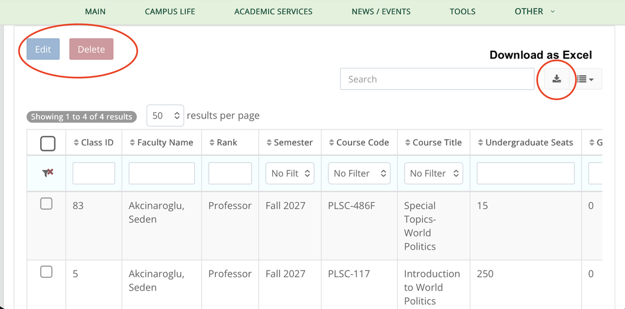

Once you press submit at the bottom of the page, you can view entries in the “Planning Sheet” tab at the top — you can also edit or delete entries using the buttons on the top left. You can also download an excel version of the curricular planning form once you’ve completed data entry.

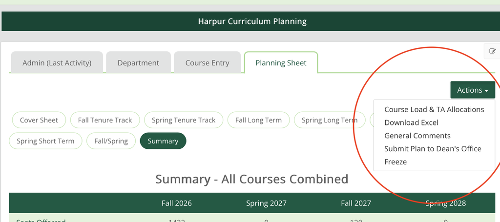

On the “Planning Sheet” tab, use the **Actions** menu to:

- edit your TA allocations or teaching load;
- download your curricular plan as an Excel file;
- add general comments to the cover sheet;
- submit your plan to the Dean’s office.

**⚠ Important:** Once you submit your plan, please do not make any changes until your department meets with the Dean’s office.

## Frequently asked questions

### What should I do if an instructor is on sabbatical or has a teaching reduction?

Please indicate that in the “Course Release/Leave Type” field. Where appropriate, please add a note in the “Notes” field.

### How do I account for TAs when they will be provided to or from another department or program?

Enter the number of TAs for the class in the “TA” box; in the “Notes” field, explain the source of the TA.

### What is the “Notes” field for?

Use the “Notes” field as you normally would in the curricular planning form to convey information your department or the Dean’s office will need in order to understand the entry.

### What if I make a mistake and want to delete a course?

Go to the “Planning Sheet” tab, choose the sheet where you need to make a correction (e.g. “Spring Tenure Track”), select the check box next to the entry you want to edit or delete, then press the edit or delete button (see illustration above).

### How can I view the completed spreadsheet after submission?

At the top, right of the sheet is an icon for downloading an excel version (see illustration above).

### What does “Additional Cost (Harpur)” and “Additional Cost (Other)” mean?

These typically refer to requested Adjunct support. If you enter an Adjunct instructor, you’ll need either to request Harpur funds, or note that funding is coming from another source (e.g., the department, a grant, etc.)

### What information can I find on the “Cover Sheet” and “Course Summary Sheet”?

These sheets will give you running totals of seats at each level, TA and grader requests, and adjunct/grader spending. In addition, they show the seats your program offered/filled in the prior academic year.

### How should I handle cross-listed courses if my department is the parent department?

As usual, all seats should be allocated to the parent department, and the course should only appear in the Curricular Plan of the parent department. You can note the cross listings in the “Notes” field.

### How should I handle a 400-level course cross-listed with a 500-level course?

Enter the course twice, once for the 400-level with undergraduate seats, once for the 500-level with graduate seats. This will appear as 2 rows in the planning sheet.

### How do I complete this form for a faculty member with a joint appointment?

If a faculty member has a joint appointment with another department, please note this in the notes section. This helps explain why they are teaching fewer courses in your department and indicates that we should look for courses in another department.

### How do I indicate my department is assigning a TA to another department or program?

If your department allocates a TA to another department or program, add that TA to the short term page as either College or Unit Funded; enter a class as 1xx, title TBD, 1 undergrad seat. Please enter “1” in the TA column as this indicates a TA is assigned here. In the notes field, please indicate where the TA is assigned (e.g. to department XX).

### How do I edit my TA allocations or teaching load?

On the “Planning Sheet” tab, open the **Actions** menu and choose the option to edit your TA allocations or teaching load.

### How do I indicate a TA is teaching their own course as instructor of record?

On the “Course Entry” tab, enter the TA’s name as the instructor; choose either “College Funded” or “Unit Funded” in the “Rank” field; in the “Number of TAs” field, enter “1”. This course will appear in the short term pages.

### How do I download my curricular plan as an Excel file?

On the “Planning Sheet” tab, open the **Actions** menu and choose the option to download your curricular plan as an Excel file.

### How do I add general comments to the cover sheet?

On the “Planning Sheet” tab, open the **Actions** menu and choose the option to add general comments to the cover sheet.

### How do I submit my plan to the Dean’s office?

On the “Planning Sheet” tab, open the **Actions** menu and choose the option to submit your plan to the Dean’s office.

**⚠ Important:** Once you submit your plan, please do not make any changes until your department meets with the Dean’s office.

### Who should I contact if I have technical issues with the form?

If you encounter any technical issues or have questions that aren’t answered here, please contact Dave Clark in the Harpur Dean’s office.